```python
# Time package
import time
from tqdm import tqdm

# Scrapping package
from selenium import webdriver
from selenium.webdriver.common.by import By
from selenium.webdriver.common.keys import Keys
from selenium.webdriver.support.ui import WebDriverWait
from selenium.webdriver.support import expected_conditions as EC
from helium import *

# Pandas, Numpy and sklearn package
import numpy as np
import pandas as pd
from sklearn.model_selection import train_test_split,GridSearchCV,cross_val_score,KFold
from sklearn.metrics import cohen_kappa_score,accuracy_score,mean_squared_error,mean_absolute_error,roc_curve,plot_roc_curve,roc_auc_score,mean_absolute_percentage_error,r2_score
from sklearn.feature_extraction.text import TfidfVectorizer
from sklearn.ensemble import RandomForestRegressor,AdaBoostRegressor,GradientBoostingRegressor
from sklearn.pipeline import Pipeline

# Visualization package
import matplotlib.pyplot as plt
import seaborn as sns
from wordcloud import WordCloud

# NLP package
import re
import nltk
from nltk.tokenize import word_tokenize
from nltk.stem import WordNetLemmatizer
import string
from nltk.corpus import stopwords
from num2words import num2words
from textblob import TextBlob
import gensim
from gensim import corpora
import pyLDAvis
import pyLDAvis.gensim_models
from gensim.models.coherencemodel import CoherenceModel

# Other
import warnings
warnings.filterwarnings("ignore")
```

# Module 1

## Most popular news in recent time

1. This module collects information about most popular news in recent time.
2. Here, data from 'WION' news channel is collected.
3. The data consists of recent news topic, duration of video, views, upload date.
4. From this data, information is collected and analysis is done.
5. This module is purely based on selenium
6. In later stage, when i was looking for the documentation i discovered helium which provides the wrapper around selenium

```python
channel_name='wion'
url='https://www.youtube.com/c/'+channel_name+'/videos'
print(url)
```

```
https://www.youtube.com/c/wion/videos
```

```python
# Initializing driver
print('Initializing driver.....')
driver = webdriver.Chrome()
wait = WebDriverWait(driver, 3)
presence = EC.presence_of_element_located
visible = EC.visibility_of_element_located

# Navigate to url


driver.get(url)
print('Navigating to URL.....')
driver.maximize_window()
driver.implicitly_wait(3)
time.sleep(2)

# Sorting by most popular

driver.find_element_by_id("icon-label").click()
time.sleep(1)
print('Sorting by most popular news.....')
sort=driver.find_element_by_xpath("""/html/body/ytd-app/div[1]/ytd-page-manager/ytd-browse[1]/ytd-two-column-browse-results-renderer/div[1]/ytd-section-list-renderer/div[1]/div[2]/ytd-channel-sub-menu-renderer/div[2]/yt-sort-filter-sub-menu-renderer/yt-dropdown-menu/tp-yt-paper-menu-button/tp-yt-iron-dropdown/div/div/tp-yt-paper-listbox/a[1]/tp-yt-paper-item/tp-yt-paper-item-body/div[1]""")
time.sleep(1)
sort.click()

# Scrolling to get top 1000 news title
print('Scraping started.....')
prev_h=0
for i in tqdm(range(300)):
    height = driver.execute_script("""
                function getActualHeight() {
                    return Math.max(
                        Math.max(document.body.scrollHeight, document.documentElement.scrollHeight),
                        Math.max(document.body.offsetHeight, document.documentElement.offsetHeight),
                        Math.max(document.body.clientHeight, document.documentElement.clientHeight)
                    );
                }
                return getActualHeight();
            """)
    driver.execute_script(f"window.scrollTo({prev_h},{prev_h + 300})")
    time.sleep(1)
    prev_h +=400
print('Scraping done...creating raw output file.....')
info_box=[i.text for i in driver.find_elements_by_id('dismissible')]
print('Output file created successfully.....')
driver.quit()
```

```
Initializing driver.....
Navigating to URL.....
Sorting by most popular news.....
```

```
Scraping started.....
```

```
Scraping done...creating raw output file.....
Output file created successfully.....
```

### Data cleaning

```python
len(info_box)
```

```
998
```

```python
info_box[0].split('\n')
```

```
['9:26',
 'Gravitas Plus | Explained: The Russia-Ukraine crisis',
 '26M views',
 '4 months ago']
```

```python
duration=[]
news_heading=[]
views=[]
upload_time=[]
for i in info_box:
    dummy=i.split('\n')
    if len(dummy)<=3:
        pass
    else:
        duration.append(dummy[0])
        news_heading.append(dummy[1])
        views.append(dummy[2].split()[0])
        upload_time.append(dummy[3])
```

```python
raw_data=pd.DataFrame({
    'News_Heading':news_heading,
    'Duration':duration,
    'Views':views,
    'Upload_Datetime':upload_time
})

raw_data.head()
```

|  | News_Heading | Duration | Views | Upload_Datetime |
| --- | --- | --- | --- | --- |
| 0 | Gravitas Plus \| Explained: The Russia-Ukraine ... | 9:26 | 26M | 4 months ago |
| 1 | Russian President Vladimir Putin sets conditio... | 1:53 | 6.1M | 3 months ago |
| 2 | Gravitas: Belarus leader's blunder reveals Put... | 5:54 | 6M | 3 months ago |
| 3 | WION Ground Report: Kabul's first morning unde... | 5:25 | 5.7M | 10 months ago |
| 4 | What happened, when Trump didn't know he was a... | 2:59 | 5.5M | 2 years ago |

```python
# Converting into single unit
upt=[]
for i in raw_data['Upload_Datetime']:
    lst=i.split('Streamed',1)[-1].strip().split()
    if 'minutes' in lst:
        upt.append(1)
    elif 'minute' in lst:
        upt.append(1)
    elif 'day' in lst:
        upt.append(int(lst[0]))
    elif 'days' in lst:
        upt.append(int(lst[0]))
    elif 'week' in lst:
        upt.append(int(lst[0])*7)
    elif 'weeks' in lst:
        upt.append(int(lst[0])*7)
    elif 'month' in lst:
        upt.append(int(lst[0])*30)
    elif 'months' in lst:
        upt.append(int(lst[0])*30)
    elif 'year' in lst:
        upt.append(int(lst[0])*12*30)
    elif 'years' in lst:
        upt.append(int(lst[0])*12*30)
    else:
        upt.append(1)

raw_data['Days_from_upload']=upt
raw_data.head()
```

|  | News_Heading | Duration | Views | Upload_Datetime | Days_from_upload |
| --- | --- | --- | --- | --- | --- |
| 0 | Gravitas Plus \| Explained: The Russia-Ukraine ... | 9:26 | 26M | 4 months ago | 120 |
| 1 | Russian President Vladimir Putin sets conditio... | 1:53 | 6.1M | 3 months ago | 90 |
| 2 | Gravitas: Belarus leader's blunder reveals Put... | 5:54 | 6M | 3 months ago | 90 |
| 3 | WION Ground Report: Kabul's first morning unde... | 5:25 | 5.7M | 10 months ago | 300 |
| 4 | What happened, when Trump didn't know he was a... | 2:59 | 5.5M | 2 years ago | 720 |

```python
clean_views=[]
for i in raw_data.Views:
    dum=list(i)
    if 'K' in dum:
        clean_views.append(float(i.split('K')[0])*1000)
    elif 'M' in dum:
        clean_views.append(float(i.split('M')[0])*1000000)
    else:
        clean_views.append(float(i.split()[0]))

raw_data['Clean_views']=clean_views
raw_data.head()
```

|  | News_Heading | Duration | Views | Upload_Datetime | Days_from_upload | Clean_views |
| --- | --- | --- | --- | --- | --- | --- |
| 0 | Gravitas Plus \| Explained: The Russia-Ukraine ... | 9:26 | 26M | 4 months ago | 120 | 26000000.0 |
| 1 | Russian President Vladimir Putin sets conditio... | 1:53 | 6.1M | 3 months ago | 90 | 6100000.0 |
| 2 | Gravitas: Belarus leader's blunder reveals Put... | 5:54 | 6M | 3 months ago | 90 | 6000000.0 |
| 3 | WION Ground Report: Kabul's first morning unde... | 5:25 | 5.7M | 10 months ago | 300 | 5700000.0 |
| 4 | What happened, when Trump didn't know he was a... | 2:59 | 5.5M | 2 years ago | 720 | 5500000.0 |

```python
raw_data['Views_per_day']=round(raw_data['Clean_views']/raw_data['Days_from_upload'])
raw_data.head()
```

|  | News_Heading | Duration | Views | Upload_Datetime | Days_from_upload | Clean_views | Views_per_day |
| --- | --- | --- | --- | --- | --- | --- | --- |
| 0 | Gravitas Plus \| Explained: The Russia-Ukraine ... | 9:26 | 26M | 4 months ago | 120 | 26000000.0 | 216667.0 |
| 1 | Russian President Vladimir Putin sets conditio... | 1:53 | 6.1M | 3 months ago | 90 | 6100000.0 | 67778.0 |
| 2 | Gravitas: Belarus leader's blunder reveals Put... | 5:54 | 6M | 3 months ago | 90 | 6000000.0 | 66667.0 |
| 3 | WION Ground Report: Kabul's first morning unde... | 5:25 | 5.7M | 10 months ago | 300 | 5700000.0 | 19000.0 |
| 4 | What happened, when Trump didn't know he was a... | 2:59 | 5.5M | 2 years ago | 720 | 5500000.0 | 7639.0 |

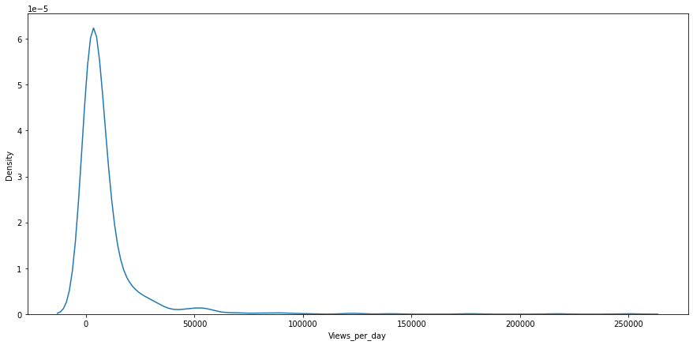

```python
plt.figure(figsize=(15,7))
sns.kdeplot(raw_data['Views_per_day']);
```

```python
raw_data.describe()
```

|  | Days_from_upload | Clean_views | Views_per_day |
| --- | --- | --- | --- |
| count | 991.000000 | 9.910000e+02 | 991.000000 |
| mean | 304.242180 | 1.002087e+06 | 9031.709384 |
| std | 309.067287 | 1.098681e+06 | 17848.986672 |
| min | 4.000000 | 4.720000e+05 | 283.000000 |
| 25% | 90.000000 | 5.560000e+05 | 1845.500000 |
| 50% | 240.000000 | 7.090000e+05 | 4000.000000 |
| 75% | 360.000000 | 1.000000e+06 | 8491.500000 |
| max | 1800.000000 | 2.600000e+07 | 250000.000000 |

```python
raw_data.to_csv('cleaned_most_popular_news.csv')
```

```python
df=pd.read_csv('cleaned_most_popular_news.csv')
df.head()
```

|  | Unnamed: 0 | News_Heading | Duration | Views | Upload_Datetime | Days_from_upload | Clean_views | Views_per_day |
| --- | --- | --- | --- | --- | --- | --- | --- | --- |
| 0 | 0 | Gravitas Plus \| Explained: The Russia-Ukraine ... | 9:26 | 26M | 4 months ago | 120 | 26000000.0 | 216667.0 |
| 1 | 1 | Russian President Vladimir Putin sets conditio... | 1:53 | 6.1M | 3 months ago | 90 | 6100000.0 | 67778.0 |
| 2 | 2 | Gravitas: Belarus leader's blunder reveals Put... | 5:54 | 6M | 3 months ago | 90 | 6000000.0 | 66667.0 |
| 3 | 3 | WION Ground Report: Kabul's first morning unde... | 5:25 | 5.7M | 10 months ago | 300 | 5700000.0 | 19000.0 |
| 4 | 4 | What happened, when Trump didn't know he was a... | 2:59 | 5.5M | 2 years ago | 720 | 5500000.0 | 7639.0 |

```python
# Top 10 news as per views per day

df.sort_values(by='Views_per_day',ascending=False)[:10]
```

|  | Unnamed: 0 | News_Heading | Duration | Views | Upload_Datetime | Days_from_upload | Clean_views | Views_per_day |
| --- | --- | --- | --- | --- | --- | --- | --- | --- |
| 270 | 270 | US President Joe Biden falls off bike during t... | 1:21 | 1M | 4 days ago | 4 | 1000000.0 | 250000.0 |
| 0 | 0 | Gravitas Plus \| Explained: The Russia-Ukraine ... | 9:26 | 26M | 4 months ago | 120 | 26000000.0 | 216667.0 |
| 6 | 6 | Gravitas Plus: Which countries could go the Sr... | 9:32 | 5.3M | 1 month ago | 30 | 5300000.0 | 176667.0 |
| 15 | 15 | Gravitas: Taiwan "surrounded" by Chinese warsh... | 6:04 | 4.2M | 1 month ago | 30 | 4200000.0 | 140000.0 |
| 45 | 45 | Gravitas: MI6 makes a wild claim, says Putin c... | 3:23 | 2.6M | 3 weeks ago | 21 | 2600000.0 | 123810.0 |
| 91 | 91 | Gravitas: Gulf states slam India for ‘insultin... | 6:43 | 1.7M | 2 weeks ago | 14 | 1700000.0 | 121429.0 |
| 224 | 224 | War of words over Taiwan: 'We do not support T... | 10:34 | 1.1M | 11 days ago | 11 | 1100000.0 | 100000.0 |
| 829 | 829 | Gravitas: Human trash found on Mars | 3:09 | 552K | 6 days ago | 6 | 552000.0 | 92000.0 |
| 850 | 850 | Gravitas: Russia-India trade in Rupees? | 5:00 | 537K | 6 days ago | 6 | 537000.0 | 89500.0 |
| 44 | 44 | Gravitas: How Mark Zuckerberg lost his fortune | 7:02 | 2.6M | 1 month ago | 30 | 2600000.0 | 86667.0 |

```python
lem=WordNetLemmatizer()
stop_words=stopwords.words('english')
news_list=list(df['News_Heading'])
tokenized=[nltk.pos_tag(word_tokenize(i)) for i in news_list]
cleaned=[]
unwanted_words=['gravitas','news','exclusive','english','wion','latest','live','reports','world','palki','sharma']
for i in tokenized:
    dummy=[]
    for j in i:
        if j[1].startswith('NN'):
            text=''.join([t for t in j[0] if t.isalpha()])
            if len(text)>2:
                dummy.append(lem.lemmatize(text))
    clean1=[d for d in dummy if d not in stop_words]
    clean2=[c for c in clean1 if c not in string.punctuation]
    clean3=[f.lower() for f in clean2 if f.lower() not in unwanted_words]
    cleaned.append(clean3)
```

```python
cleaned[99]
```

```
['response', 'sanction', 'president', 'putin', 'threat', 'war']
```

```python
dff=pd.DataFrame({'Clean_text':cleaned,'Views_per_day':df['Views_per_day']})
dff.head()
```

|  | Clean_text | Views_per_day |
| --- | --- | --- |
| 0 | [plus, crisis] | 216667.0 |
| 1 | [president, vladimir, putin, condition, moscow... | 67778.0 |
| 2 | [belarus, leader, blunder, putin, masterplan] | 66667.0 |
| 3 | [ground, report, kabul, morning, taliban, rule... | 19000.0 |
| 4 | [trump, footages, president] | 7639.0 |

```python
dff.to_csv('final_most_popular_news.csv')
```

### Topic modelling using LDA

```python
dictionary=corpora.Dictionary(cleaned)
doc_term_mat=[dictionary.doc2bow(i) for i in cleaned]
```

```python
LDA=gensim.models.ldamodel.LdaModel
lda_model=LDA(corpus=doc_term_mat,id2word=dictionary,num_topics=8,random_state=3,per_word_topics=True)
```

```python
print(doc_term_mat[0])
```

```
[(0, 1), (1, 1)]
```

```python
lda_model.print_topics()
```

```
[(0,
  '0.042*"ukraine" + 0.037*"russia" + 0.032*"china" + 0.017*"coronavirus" + 0.016*"india" + 0.014*"conflict" + 0.012*"putin" + 0.012*"attack" + 0.012*"nato" + 0.012*"crisis"'),
 (1,
  '0.051*"china" + 0.025*"russia" + 0.022*"india" + 0.018*"ukraine" + 0.012*"taiwan" + 0.009*"conflict" + 0.009*"kyiv" + 0.009*"taliban" + 0.009*"invasion" + 0.009*"people"'),
 (2,
  '0.017*"russia" + 0.017*"india" + 0.015*"taliban" + 0.011*"zelensky" + 0.009*"border" + 0.008*"ukraine" + 0.008*"war" + 0.008*"pakistan" + 0.008*"president" + 0.008*"conflict"'),
 (3,
  '0.026*"ukraine" + 0.021*"india" + 0.017*"taliban" + 0.015*"afghanistan" + 0.009*"russia" + 0.009*"invasion" + 0.009*"israel" + 0.008*"china" + 0.008*"war" + 0.008*"president"'),
 (4,
  '0.030*"india" + 0.017*"russia" + 0.014*"kyiv" + 0.012*"putin" + 0.011*"covid" + 0.010*"china" + 0.010*"president" + 0.009*"ukraine" + 0.009*"coronavirus" + 0.009*"invasion"'),
 (5,
  '0.032*"putin" + 0.020*"ukraine" + 0.018*"biden" + 0.016*"conflict" + 0.012*"china" + 0.012*"india" + 0.012*"president" + 0.012*"vladimir" + 0.011*"joe" + 0.011*"war"'),
 (6,
  '0.041*"china" + 0.016*"russia" + 0.015*"wuhan" + 0.014*"coronavirus" + 0.013*"india" + 0.010*"ukraine" + 0.010*"covid" + 0.009*"attack" + 0.009*"report" + 0.009*"virus"'),
 (7,
  '0.048*"china" + 0.022*"coronavirus" + 0.020*"india" + 0.018*"wuhan" + 0.015*"ukraine" + 0.011*"covid" + 0.010*"vaccine" + 0.009*"taiwan" + 0.009*"pakistan" + 0.007*"war"')]
```

```python
pyLDAvis.enable_notebook()
vis=pyLDAvis.gensim_models.prepare(lda_model,doc_term_mat,dictionary)
vis
```

[interactive chart not shown]

```python
print('Perplexity = ',round(lda_model.log_perplexity(doc_term_mat),3))
coh_model_lda=CoherenceModel(model=lda_model,texts=cleaned,dictionary=dictionary,coherence='c_v')
coh_lda=coh_model_lda.get_coherence()
print('Coherence  = ',round(coh_lda,3))
```

```
Perplexity =  -7.61
Coherence  =  0.526
```

```python
score=[]
for i in range(2,12):
    lda_model=LDA(corpus=doc_term_mat,id2word=dictionary,num_topics=i,random_state=3)
    coh_model_lda=CoherenceModel(model=lda_model,texts=cleaned,dictionary=dictionary,coherence='c_v')
    coh_lda=coh_model_lda.get_coherence()
    score.append(coh_lda)
    print('Topics = ',i,'Coherence = ',round(coh_lda,3))
```

```
Topics =  2 Coherence =  0.513
Topics =  3 Coherence =  0.501
Topics =  4 Coherence =  0.536
Topics =  5 Coherence =  0.514
Topics =  6 Coherence =  0.517
Topics =  7 Coherence =  0.544
Topics =  8 Coherence =  0.526
Topics =  9 Coherence =  0.538
Topics =  10 Coherence =  0.542
Topics =  11 Coherence =  nan
```

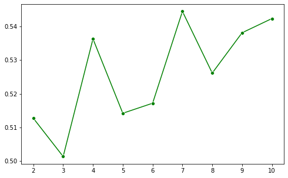

```python
plt.figure(figsize=(8,5))
sns.lineplot(x=range(2,12),y=score,color='green', marker='o');
```

```python
lda_model=LDA(corpus=doc_term_mat,id2word=dictionary,num_topics=4,random_state=3)
vis=pyLDAvis.gensim_models.prepare(lda_model,doc_term_mat,dictionary)
vis
```

[interactive chart not shown]

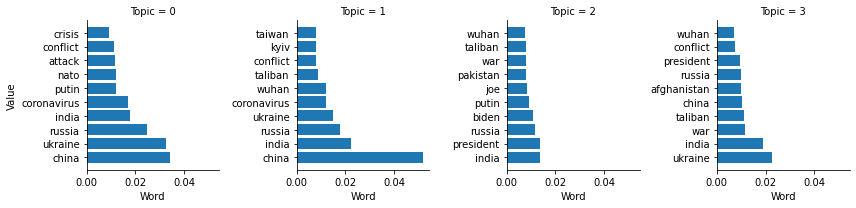

```python
topic_word=pd.DataFrame({})
for i,topic in enumerate(lda_model.get_topics()):
    du= topic.argsort()[-10:][::-1]
    feature=topic[du]
    words=[dictionary[i] for i in du]
    df1=pd.DataFrame({'Value':feature,'Word':words,'Topic':i})
    topic_word=pd.concat([topic_word,df1],ignore_index=True)

faced_grid=sns.FacetGrid(topic_word,col='Topic',col_wrap=4,sharey=False)
faced_grid.map(plt.barh,'Word','Value')
```

```python
info = lda_model.show_topics(formatted=False)
topics_words = [(topic[0], [topic_wd[0] for topic_wd in topic[1]]) for topic in info]
```

```python
topics_words[0]
```

```
(0,
 ['china',
  'ukraine',
  'russia',
  'india',
  'coronavirus',
  'putin',
  'nato',
  'attack',
  'conflict',
  'crisis'])
```

```python
df=pd.DataFrame(topics_words,columns=['Topic_Name','Topic_words'])
print(df)
```

```
   Topic_Name                                        Topic_words
0           0  [china, ukraine, russia, india, coronavirus, p...
1           1  [china, india, russia, ukraine, coronavirus, w...
2           2  [india, president, russia, biden, putin, joe, ...
3           3  [ukraine, india, war, taliban, china, afghanis...
```

```python
for topic,words in topics_words:
    print('Topic_Name',str(topic)+ "==="+ str(words))
print()
```

```
Topic_Name 0===['china', 'ukraine', 'russia', 'india', 'coronavirus', 'putin', 'nato', 'attack', 'conflict', 'crisis']
Topic_Name 1===['china', 'india', 'russia', 'ukraine', 'coronavirus', 'wuhan', 'taliban', 'conflict', 'kyiv', 'taiwan']
Topic_Name 2===['india', 'president', 'russia', 'biden', 'putin', 'joe', 'pakistan', 'war', 'taliban', 'wuhan']
Topic_Name 3===['ukraine', 'india', 'war', 'taliban', 'china', 'afghanistan', 'russia', 'president', 'conflict', 'wuhan']
```

```python
name=['Russia-Ukraine conflict','Coronavirus & other conflicts','India and world','Taliban issue']
df['Topic_Name']=name
df.set_index('Topic_Name',inplace=True)
print(df)
```

```
                                                                     Topic_words
Topic_Name
Russia-Ukraine conflict        [china, ukraine, russia, india, coronavirus, p...
Coronavirus & other conflicts  [china, india, russia, ukraine, coronavirus, w...
India and world                [india, president, russia, biden, putin, joe, ...
Taliban issue                  [ukraine, india, war, taliban, china, afghanis...
```

```python
df.to_csv('Final_Report_on_most_popular_news')
```

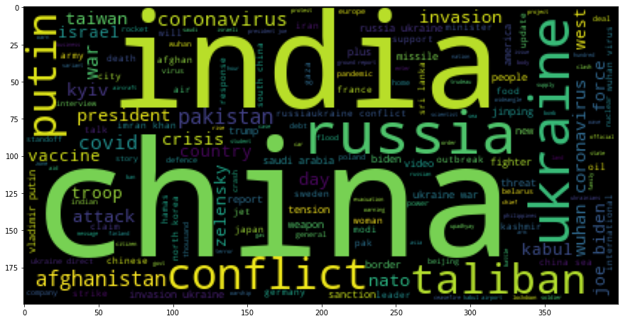

```python
wordcloud=[]
for i in cleaned:
    for j in i:
        wordcloud.append(j)
text=' '.join(i for i in wordcloud)
plt.figure(figsize=(15,10))
a1=WordCloud(background_color='black').generate(text)
plt.imshow(a1);
```

# Module 2

## latest news in recent time & data from 3 channels

1. This module collects information about latest news in recent time.
2. Here, data from 'WION','BBC News' & 'AL Jazeera' news channel is collected so that the data is not biased.
3. The data consists of recent news topic, duration of video, views, upload date.
4. From this data, information is collected and analysis is done.
5. Controlling the browser and navigating is much easier in helium.
6. We can also use combination of both.
7. I prefer selenium for extracting data since i have developed good grip on it while making this project.
8. And i prefer helium for controlling the browser.

```python
# Initializing driver
print('Initializing driver.....')
driver = start_chrome(maximize=True)
channel_name=['wion','bbc news','Al Jazeera English']
scrapped_text=[]


# Navigate to url

for c in channel_name:
    print('Navigating to URL.....')
    go_to(('https://www.youtube.com/c/'+c+'/videos'))
    time.sleep(2)

    print(f"Scraping for {c}")
    time.sleep(2)
    h=0
    for i in tqdm(range(50)):
        scroll_down(h)
        time.sleep(1)
        h+=300
    time.sleep(5)
    box=[i.text for i in driver.find_elements_by_id('dismissible')]
    scrapped_text.append(box)
raw_text=[]
for i in scrapped_text:
    for j in i:
        raw_text.append(j)
print('Scraping done.....raw output file created.')
driver.quit()
```

```
Initializing driver.....
Navigating to URL.....
Scraping for wion
```

```
Navigating to URL.....
Scraping for bbc news
```

```
Navigating to URL.....
Scraping for Al Jazeera English
```

```
Scraping done.....raw output file created.
```

```python
len(raw_text)
```

```
3926
```

```python
raw_text[0]
```

```
'2:15\nSri Lanka economic crisis: Indian officials hold talks on additional aid| World News | WION Dispatch\n1.1K views\n28 minutes ago'
```

```python
raw_text[2000].split('\n')
```

```
['1:08',
 'Toddler tossed to safety from burning building - BBC News',
 '88K views',
 '3 months ago']
```

```python
duration=[]
news_heading=[]
views=[]
upload_time=[]
for i in raw_text:
    dummy=i.split('\n')
    if len(dummy)<=3:
        pass
    else:
        duration.append(dummy[0])
        news_heading.append(dummy[1])
        views.append(dummy[2].split()[0])
        upload_time.append(dummy[3])
```

```python
raw_data=pd.DataFrame({
    'News_Heading':news_heading,
    'Duration':duration,
    'Views':views,
    'Upload_Datetime':upload_time
})

raw_data.head()
```

|  | News_Heading | Duration | Views | Upload_Datetime |
| --- | --- | --- | --- | --- |
| 0 | Sri Lanka economic crisis: Indian officials ho... | 2:15 | 1.1K | 28 minutes ago |
| 1 | Cash-strapped Pakistan to get $2.3 billion loa... | 3:28 | 6.9K | 1 hour ago |
| 2 | BRICS Summit 2022: Xi warns against expanding ... | 14:47 | 12K | 1 hour ago |
| 3 | 14th BRICS Summit: Russia trying to forge clos... | 6:09 | 16K | 1 hour ago |
| 4 | Jupiter consumes other planets? What this new ... | 1:26 | 2.5K | 1 hour ago |

```python
raw_data.shape
```

```
(2582, 4)
```

```python
upt=[]
for i in raw_data['Upload_Datetime']:
    lst=i.split('Streamed',1)[-1].strip().split()
    if 'minutes' in lst:
        upt.append(1)
    elif 'minute' in lst:
        upt.append(1)
    elif 'day' in lst:
        upt.append(int(lst[0]))
    elif 'days' in lst:
        upt.append(int(lst[0]))
    elif 'week' in lst:
        upt.append(int(lst[0])*7)
    elif 'weeks' in lst:
        upt.append(int(lst[0])*7)
    elif 'month' in lst:
        upt.append(int(lst[0])*30)
    elif 'months' in lst:
        upt.append(int(lst[0])*30)
    elif 'year' in lst:
        upt.append(int(lst[0])*12*30)
    elif 'years' in lst:
        upt.append(int(lst[0])*12*30)
    else:
        upt.append(1)
```

```python
raw_data['Days_from_upload']=upt
raw_data.head()
```

|  | News_Heading | Duration | Views | Upload_Datetime | Days_from_upload |
| --- | --- | --- | --- | --- | --- |
| 0 | Sri Lanka economic crisis: Indian officials ho... | 2:15 | 1.1K | 28 minutes ago | 1 |
| 1 | Cash-strapped Pakistan to get $2.3 billion loa... | 3:28 | 6.9K | 1 hour ago | 1 |
| 2 | BRICS Summit 2022: Xi warns against expanding ... | 14:47 | 12K | 1 hour ago | 1 |
| 3 | 14th BRICS Summit: Russia trying to forge clos... | 6:09 | 16K | 1 hour ago | 1 |
| 4 | Jupiter consumes other planets? What this new ... | 1:26 | 2.5K | 1 hour ago | 1 |

```python
clean_views=[]
for i in raw_data.Views:
    dum=list(i)
    if 'K' in dum:
        clean_views.append(float(i.split('K')[0])*1000)
    elif 'M' in dum:
        clean_views.append(float(i.split('M')[0])*1000000)
    else:
        clean_views.append(float(i.split()[0]))

raw_data['Clean_views']=clean_views
raw_data.head()
```

|  | News_Heading | Duration | Views | Upload_Datetime | Days_from_upload | Clean_views |
| --- | --- | --- | --- | --- | --- | --- |
| 0 | Sri Lanka economic crisis: Indian officials ho... | 2:15 | 1.1K | 28 minutes ago | 1 | 1100.0 |
| 1 | Cash-strapped Pakistan to get $2.3 billion loa... | 3:28 | 6.9K | 1 hour ago | 1 | 6900.0 |
| 2 | BRICS Summit 2022: Xi warns against expanding ... | 14:47 | 12K | 1 hour ago | 1 | 12000.0 |
| 3 | 14th BRICS Summit: Russia trying to forge clos... | 6:09 | 16K | 1 hour ago | 1 | 16000.0 |
| 4 | Jupiter consumes other planets? What this new ... | 1:26 | 2.5K | 1 hour ago | 1 | 2500.0 |

```python
raw_data['Views_per_day']=round(raw_data['Clean_views']/raw_data['Days_from_upload'])
raw_data.head()
```

|  | News_Heading | Duration | Views | Upload_Datetime | Days_from_upload | Clean_views | Views_per_day |
| --- | --- | --- | --- | --- | --- | --- | --- |
| 0 | Sri Lanka economic crisis: Indian officials ho... | 2:15 | 1.1K | 28 minutes ago | 1 | 1100.0 | 1100.0 |
| 1 | Cash-strapped Pakistan to get $2.3 billion loa... | 3:28 | 6.9K | 1 hour ago | 1 | 6900.0 | 6900.0 |
| 2 | BRICS Summit 2022: Xi warns against expanding ... | 14:47 | 12K | 1 hour ago | 1 | 12000.0 | 12000.0 |
| 3 | 14th BRICS Summit: Russia trying to forge clos... | 6:09 | 16K | 1 hour ago | 1 | 16000.0 | 16000.0 |
| 4 | Jupiter consumes other planets? What this new ... | 1:26 | 2.5K | 1 hour ago | 1 | 2500.0 | 2500.0 |

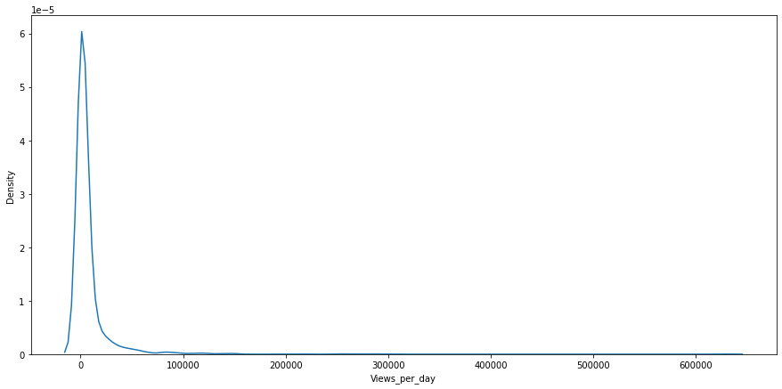

```python
plt.figure(figsize=(15,7))
sns.kdeplot(raw_data['Views_per_day']);
```

```python
raw_data.describe()
```

|  | Days_from_upload | Clean_views | Views_per_day |
| --- | --- | --- | --- |
| count | 2582.000000 | 2.582000e+03 | 2582.000000 |
| mean | 37.427576 | 1.631132e+05 | 7844.666538 |
| std | 41.011248 | 5.264281e+05 | 24930.778430 |
| min | 1.000000 | 9.780000e+02 | 43.000000 |
| 25% | 9.000000 | 8.700000e+03 | 500.000000 |
| 50% | 21.000000 | 2.450000e+04 | 1382.000000 |
| 75% | 60.000000 | 1.000000e+05 | 5029.000000 |
| max | 180.000000 | 1.000000e+07 | 630000.000000 |

```python
raw_data.to_csv('cleaned_latest_news.csv')
```

```python
df=pd.read_csv('cleaned_latest_news.csv')
df.head()
```

|  | Unnamed: 0 | News_Heading | Duration | Views | Upload_Datetime | Days_from_upload | Clean_views | Views_per_day |
| --- | --- | --- | --- | --- | --- | --- | --- | --- |
| 0 | 0 | Sri Lanka economic crisis: Indian officials ho... | 2:15 | 1.1K | 28 minutes ago | 1 | 1100.0 | 1100.0 |
| 1 | 1 | Cash-strapped Pakistan to get $2.3 billion loa... | 3:28 | 6.9K | 1 hour ago | 1 | 6900.0 | 6900.0 |
| 2 | 2 | BRICS Summit 2022: Xi warns against expanding ... | 14:47 | 12K | 1 hour ago | 1 | 12000.0 | 12000.0 |
| 3 | 3 | 14th BRICS Summit: Russia trying to forge clos... | 6:09 | 16K | 1 hour ago | 1 | 16000.0 | 16000.0 |
| 4 | 4 | Jupiter consumes other planets? What this new ... | 1:26 | 2.5K | 1 hour ago | 1 | 2500.0 | 2500.0 |

```python
df.shape
```

```
(2582, 8)
```

```python
# Top 10 news as per views per day

df.sort_values(by='Views_per_day',ascending=False)[:10]
```

|  | Unnamed: 0 | News_Heading | Duration | Views | Upload_Datetime | Days_from_upload | Clean_views | Views_per_day |
| --- | --- | --- | --- | --- | --- | --- | --- | --- |
| 936 | 936 | Half Russian separatist force in Ukraine 'dead... | 2:43 | 630K | 1 day ago | 1 | 630000.0 | 630000.0 |
| 59 | 59 | Gravitas: Russian Rouble surges as Asian curre... | 5:39 | 304K | 21 hours ago | 1 | 304000.0 | 304000.0 |
| 61 | 61 | Gravitas: Putin: Russia will use nukes to defe... | 6:45 | 290K | 22 hours ago | 1 | 290000.0 | 290000.0 |
| 968 | 968 | Russia tells BBC “we did not invade Ukraine” a... | 4:18 | 1.7M | 6 days ago | 6 | 1700000.0 | 283333.0 |
| 118 | 118 | Gravitas: Europe accused of "exploiting" fossi... | 4:51 | 278K | 1 day ago | 1 | 278000.0 | 278000.0 |
| 942 | 942 | Russia has 'almost captured' city of Severodon... | 4:31 | 267K | 1 day ago | 1 | 267000.0 | 267000.0 |
| 931 | 931 | Russia warns Lithuania of consequences over ra... | 3:25 | 256K | 7 hours ago | 1 | 256000.0 | 256000.0 |
| 227 | 227 | US President Joe Biden falls off bike during t... | 1:21 | 1M | 4 days ago | 4 | 1000000.0 | 250000.0 |
| 40 | 40 | BRICS summit 2022: Xi Jinping warns about 'exp... | 4:20 | 216K | 13 hours ago | 1 | 216000.0 | 216000.0 |
| 113 | 113 | Gravitas: Mysterious rocks to reveal secrets o... | 2:40 | 152K | 1 day ago | 1 | 152000.0 | 152000.0 |